# Figure 4: RIG-I-only and STAT-only programs in cervical cancer spatial transcriptomics

Carlos Ramirez

2026-10-27 17:03:55

This document reproduces the panels of **Figure 4**, in which the RIG-I-only and STAT-only (IFN-only) signatures defined in Figure 1 are evaluated in a cervical squamous cell carcinoma sample profiled with 10x Genomics Xenium (whole-transcriptome preview panel, FFPE). The figure shows:

1. `ranked_cell_types_rigi_only_cc.pdf` – the six Xenium cell types with the highest median RIG-I-only score. To avoid that the score is driven by a generic NF-kB/TNF response, the RIG-I-only genes that are also part of the MSigDB `HALLMARK_TNFA_SIGNALING_VIA_NFKB` set are removed before scoring (score `rigi_specific1`).
2. `ranked_cell_types_stat_only_cc.pdf` – the six Xenium cell types with the highest median STAT-only score (`stat_only1`).
3. `distance_to_rigi_high.pdf` – the STAT-only score of every Xenium cell as a function of its distance to the nearest RIG-I-high cell (top 10 % RIG-I-only score), compared with the distance to the nearest RIG-I-low cell (bottom 10 %, control reference). Points are medians, error bars the IQR.

The code was extracted from the original analysis scripts `/media/ag-cherrmann/cramirez/interferon_model/scripts/R/july_2026/04_cervical_cancer_scRNASeq_analysis.Rmd` (panels 1 and 2) and `/media/ag-cherrmann/cramirez/interferon_model/scripts/R/july_2026/04_cervical_cancer_cell_communication.Rmd` (panel 3). Only the code needed for these panels (and its upstream dependencies) is kept; plotting code and PDF sizes are unchanged.

## Input data

All paths are absolute. Data folders are treated as read-only by this document.

**Xenium spatial transcriptomics (cervical cancer)**

- Dataset: 10x Genomics *Xenium Prime / WTA Preview – FFPE Human Cervical Cancer* (`WTA_Preview_FFPE_Cervical_Cancer`), downloaded from the 10x Genomics datasets portal. Raw archives: `/media/bq-storage/ag-cherrmann/cramirez/data/spat_trans/cervical_cancer/WTA_Preview_FFPE_Cervical_Cancer_outs.zip` and `/media/bq-storage/ag-cherrmann/cramirez/data/spat_trans/cervical_cancer/WTA_Preview_FFPE_Cervical_Cancer_xe_outs.zip`.
- Unpacked Xenium output folder: `/media/bq-storage/ag-cherrmann/cramirez/data/spat_trans/cervical_cancer/Xenium_output` (count matrix `cell_feature_matrix.h5`, cell centroids `cells.csv.gz`).
- Cell-type annotations provided with the dataset: `/media/bq-storage/ag-cherrmann/cramirez/data/spat_trans/cervical_cancer/WTA_Preview_FFPE_Cervical_Cancer_cell_groups.csv` (columns `cell_id`, `group`).
- Processed Seurat object (log-normalised, annotated cells only; produced by the `eval = FALSE` chunks below and loaded here): `/media/bq-storage/ag-cherrmann/cramirez/data/spat_trans/cervical_cancer/seurat_transcriptome_processed_seu.rds`.

**Derived table: `stat_scores_by_spatial_distance.tsv`** (panel 3)

`/media/bq-storage/ag-cherrmann/cramirez/data/spat_trans/cervical_cancer/stat_scores_by_spatial_distance.tsv` (717,283 cells) was generated in Python by the notebook `/media/bq-storage/ag-cherrmann/cramirez/data/spat_trans/cervical_cancer/distance_analysis.ipynb` (kernel `spatial_env`, Python 3.12; file written 2026-09-22 14:35, notebook cell 50):

1. The Xenium output folder is read with `spatialdata_io.xenium("Xenium_output")`; counts are normalised with `scanpy.pp.normalize_total` and `scanpy.pp.log1p`.
2. Cells are scored with `scanpy.tl.score_genes` using the RIG-I-only (`rigi_score`) and STAT-only (`stat_score`) gene lists hard-coded in the notebook (identical to the 94 / 99 genes in `rigi_vs_stat_only_signatures.rds`, restricted to genes in the panel).
3. Only cells in `WTA_Preview_FFPE_Cervical_Cancer_cell_groups.csv` are kept and the annotation is stored as `celltype`; centroids (`x`, `y`, µm) are taken from `obsm["spatial"]`.
4. RIG-I-high cells = `rigi_score >= 90th percentile` (0.0501); RIG-I-low cells = `rigi_score <= 10th percentile` (-0.0156).
5. For every cell the Euclidean distance to the nearest RIG-I-high and to the nearest RIG-I-low cell is computed with `scipy.spatial.cKDTree` (`distance_to_rigi_high`, `distance_to_rigi_low`).
6. The distances are binned with `pandas.cut` (left-closed bins 0, 25, 50, 75, 100, 150, 200, 300, 400 µm) into `distance_band_rigi_high` and `distance_band_rigi_low`, and the table is written as TSV.

The notebook cells were executed out of order; the column `distance_band` in the TSV comes from an earlier binning step whose cell was later overwritten. That column is not used for Figure 4.

**Gene sets**

- RIG-I-only / STAT-only signatures (defined in `figure_01.Rmd`): `/media/bq-storage/ag-cherrmann/cramirez/decoupling_rigi_ifn/analysis/figure_01/rigi_vs_stat_only_signatures.rds` (identical to the file used originally, `/media/ag-cherrmann/cramirez/interferon_model/analysis/2026_May/rigi_vs_stat_only_signatures.rds`).
- MSigDB Hallmark TNF-alpha signalling via NF-kB, downloaded at run time from https://www.gsea-msigdb.org/gsea/msigdb/human/download_geneset.jsp?geneSetName=HALLMARK_TNFA_SIGNALING_VIA_NFKB&fileType=grp (a copy of the list used in this run is written to `analysis/figure_04/`).

**Not used by these panels.** The original script also processes the cervical cancer scRNA-seq dataset of Li C. *et al.* 2022 (ArrayExpress E-MTAB-11948; raw 10x matrices in `/media/bq-storage/ag-cherrmann/cramirez/data/cervical_cancer/hua_2022/E-MTAB-11948`, processed object `/media/bq-storage/ag-cherrmann/cramirez/data/cervical_cancer/hua_2022/E-MTAB-11948/processed_cervical_cancer_Li_2022_seu.rds`). None of the three Figure 4 panels depends on it, so that part is not included.

## Dependencies and settings

```r
library(dplyr)
library(tidyr)
library(ggplot2)
library(Seurat)
library(tibble)
```

The shared settings define the repository paths, the path to the signatures (`path2signs`) and the output folders of this section.

```r
source("/media/bq-storage/ag-cherrmann/cramirez/decoupling_rigi_ifn/scripts/R/settings.R")
```

```r
dirs <- section_dirs("figure_04")
path2figures <- dirs$figures
path2analysis <- dirs$analysis

path2xenium_data <- "/media/bq-storage/ag-cherrmann/cramirez/data/spat_trans/cervical_cancer"
```

## Processing of the Xenium dataset (not re-run)

The following two chunks show how the processed Seurat object `seurat_transcriptome_processed_seu.rds` was generated from the raw Xenium output: the count matrix is loaded, the dataset cell-type annotations are added, only annotated cells are kept, and the data are log-normalised (plus HVG/PCA/UMAP, not used here). They are kept for documentation with `eval = FALSE`; the cached object is loaded below.

```r
xenium_dir <- "/media/bq-storage/ag-cherrmann/cramirez/data/spat_trans/cervical_cancer/Xenium_output"
xenium_counts <- Read10X_h5(
    filename = file.path(xenium_dir, "cell_feature_matrix.h5")
)
dim(xenium_counts$`Gene Expression`)

spat_anns_path <- "/media/bq-storage/ag-cherrmann/cramirez/data/spat_trans/cervical_cancer/WTA_Preview_FFPE_Cervical_Cancer_cell_groups.csv"
spat_anns <- readr::read_csv(spat_anns_path)

seurat_xenium <- CreateSeuratObject(
    counts = xenium_counts$`Gene Expression`,
    project = "CervicalCancer_Xenium",
    min.cells = 0,
    min.features = 0
)

seurat_xenium$"cell_type" <- plyr::mapvalues(
        x = colnames(seurat_xenium),
        from = spat_anns$cell_id,
        to = spat_anns$group,
        warn_missing = FALSE
)
```

```r
## Using only annotated cells
seurat_xenium <- seurat_xenium[, colnames(seurat_xenium) %in% spat_anns$cell_id]

# 1. Log-normalization
seurat_xenium <- NormalizeData(
    seurat_xenium,
    normalization.method = "LogNormalize",
    scale.factor = 10000,
    verbose = TRUE
)

# 2. Identify variable features
seurat_xenium <- FindVariableFeatures(
    seurat_xenium,
    selection.method = "vst",
    nfeatures = 3000,
    verbose = TRUE
)

# 3. Scale variable features
seurat_xenium <- ScaleData(
    seurat_xenium,
    features = VariableFeatures(seurat_xenium),
    verbose = TRUE
)

# 4. PCA
seurat_xenium <- RunPCA(
    seurat_xenium,
    features = VariableFeatures(seurat_xenium),
    npcs = 50,
    verbose = TRUE
)

# 5. Nearest-neighbor graph
seurat_xenium <- FindNeighbors(
    seurat_xenium,
    dims = 1:30,
    verbose = TRUE
)

# 6. UMAP
seurat_xenium <- RunUMAP(
    seurat_xenium,
    dims = 1:30,
    reduction = "pca",
    return.model = FALSE,
    verbose = TRUE
)

# Saving (original location; never overwritten from this document)
saveRDS(seurat_xenium,
        file = "/media/bq-storage/ag-cherrmann/cramirez/data/spat_trans/cervical_cancer/seurat_transcriptome_processed_seu.rds",
        compress = TRUE)
```

## Loading the processed Xenium object

Loading the cached, processed Seurat object (all annotated Xenium cells).

```r
seurat_xenium <- readRDS(
        file.path(path2xenium_data, "seurat_transcriptome_processed_seu.rds")
)
seurat_xenium
```

```
## An object of class Seurat
## 18028 features across 717283 samples within 1 assay
## Active assay: RNA (18028 features, 3000 variable features)
##  3 layers present: counts, data, scale.data
##  2 dimensional reductions calculated: pca, umap
```

```r
table(seurat_xenium$cell_type)
```

```
##
##                        B Cells  Cancer Associated Fibroblasts
##                          28751                          17867
##              Cytotoxic T Cells                Dendritic Cells
##                          76154                          10266
##                     Detachment    Differentiating Tumor Cells
##                           1870                          40557
##       Dyskeratotic Tumor Cells    Endocervical Ciliated Cells
##                          35576                            566
##    Endocervical Columnar Cells              Endothelial Cells
##                           1572                          23078
##              Exhausted T Cells            Hypoxic Tumor Cells
##                          12320                          52395
##       Interstitial Fibroblasts                    Macrophages
##                          24385                          42065
##                     Mast Cells Metabolic Invasive Basal Cells
##                          16024                          54402
## Migratory Invasive Basal Cells         Naive & Memory T Cells
##                          40307                          30504
##                    Neutrophils                  OR4F17+ Cells
##                          16736                           3020
##          Parabasal Tumor Cells                   Plasma Cells
##                          36648                          11614
##  Proliferative Parabasal Cells             Regulatory T Cells
##                          22119                          28967
##                  Smooth Muscle         Stroma & Smooth Muscle
##                          14210                          75310
```

Module-score columns already stored in the cached object (if any) are kept aside so they can be compared with the scores recomputed below.

```r
score_cols <- c("rigi_only2", "stat_only1", "rigi_specific1")
cached_scores <- seurat_xenium@meta.data[, intersect(score_cols,
                                                     colnames(seurat_xenium@meta.data)),
                                         drop = FALSE]
colnames(cached_scores)
```

```
## character(0)
```

## Loading the signatures

RIG-I-only and STAT-only signatures from Figure 1. As in the original script, interferon genes (IFNB/IFNL) are removed and the list is re-ordered so that the module scores are named `stat_only1` and `rigi_only2`.

```r
signatures <- readRDS(path2signs)
signatures <- lapply(signatures,
                     function(genes){
                             genes[!grepl('IFNB|IFNL', genes)]
})
signatures <- signatures[c(2,1)]
str(signatures)
```

```
## List of 2
##  $ stat_only: chr [1:99] "PNPT1" "TRIM5" "CSF1" "ZNF711" ...
##  $ rigi_only: chr [1:94] "EGR4" "CXCL11" "FOSB" "EGR2" ...
```

## Scoring the Xenium cells

Seurat module scores (`AddModuleScore`, fixed seed, hence deterministic) for the STAT-only and RIG-I-only signatures (panel 2 uses `stat_only1`).

```r
seurat_xenium <- AddModuleScore(
  object = seurat_xenium,
  features = signatures,
  assay = "RNA",
  name = names(signatures)
)
```

For panel 1, the RIG-I-only genes that also belong to the MSigDB Hallmark TNF-alpha/NF-kB gene set are removed (`rigi_specific`) and the remaining genes are scored. (As in the original, only the first line of the `.grp` file, the gene-set name, is dropped; the remaining comment line matches no gene.)

```r
nfkb_url <- "https://www.gsea-msigdb.org/gsea/msigdb/human/download_geneset.jsp?geneSetName=HALLMARK_TNFA_SIGNALING_VIA_NFKB&fileType=grp"
nfkb_sign <- readLines(nfkb_url)
nfkb_sign <- nfkb_sign[2:length(nfkb_sign)]
writeLines(nfkb_sign,
           file.path(path2analysis, "HALLMARK_TNFA_SIGNALING_VIA_NFKB.grp"))

rigi_specific <- setdiff(signatures$rigi_only, nfkb_sign)
rigi_specific_list <- list(rigi_specific=rigi_specific)
length(rigi_specific)
```

```
## [1] 64
```

```r
seurat_xenium <- AddModuleScore(
  object = seurat_xenium,
  features = rigi_specific_list,
  assay = "RNA",
  name = "rigi_specific"
  )
```

Comparison of the recomputed scores with those stored in the cached object (if present), and export of the per-cell scores.

```r
for (sc in colnames(cached_scores)) {
        d <- seurat_xenium@meta.data[rownames(cached_scores), sc] - cached_scores[[sc]]
        cat(sc, ": max |recomputed - cached| =", max(abs(d), na.rm = TRUE), "\n")
}

xenium_scores <- seurat_xenium@meta.data %>%
        rownames_to_column(var = "cell_id") %>%
        dplyr::select(cell_id, cell_type, rigi_only2, stat_only1, rigi_specific1)
readr::write_tsv(xenium_scores,
                 file.path(path2analysis, "xenium_cell_module_scores.tsv.gz"))
```

## Panel: cell types ranked by RIG-I-only score

Top six cell types by median `rigi_specific1` score (`ranked_cell_types_rigi_only_cc.pdf`).

```r
# Extract data
plot_df <- FetchData(
    seurat_xenium,
    vars = c("rigi_specific1", "cell_type")
)

# Remove rows with missing values
plot_df <- plot_df %>%
    filter(
        !is.na(cell_type),
        !is.na(rigi_specific1)
    )

# Calculate median score and rank cell types
cell_order <- plot_df %>%
    group_by(cell_type) %>%
    summarise(
        median_score = median(rigi_specific1, na.rm = TRUE),
        .groups = "drop"
    ) %>%
    arrange(median_score) %>%
    pull(cell_type)

# Select the top 6 cell types
top6_cell_types <- tail(cell_order, 6)
top6_cell_types
```

```
## [1] "Neutrophils"                 "Stroma & Smooth Muscle"
## [3] "Endocervical Columnar Cells" "Differentiating Tumor Cells"
## [5] "Endocervical Ciliated Cells" "Dyskeratotic Tumor Cells"
```

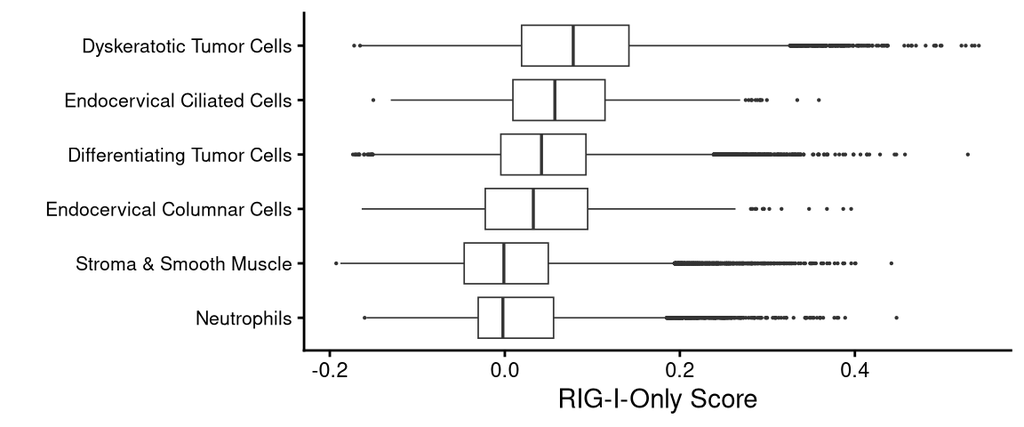

```r
# Filter BEFORE converting to factor
plot_df_top6 <- plot_df %>%
    filter(cell_type %in% top6_cell_types)

# Order the top 6 according to median score
plot_df_top6$cell_type <- factor(
    plot_df_top6$cell_type,
    levels = top6_cell_types
)

# Safety check
stopifnot(!any(is.na(plot_df_top6$cell_type)))

# Plot
boxplot_ranked_cell_types <- ggplot(
    plot_df_top6,
    aes(
        x = cell_type,
        y = rigi_specific1
    )
) +
    geom_boxplot(
        outlier.size = 0.1,
        linewidth = 0.3
    ) +
    coord_flip() +
    theme_classic() +
    labs(
        x = "",
        y = "RIG-I-Only Score"
    ) +
    theme(
        axis.text.y = element_text(size = 8)
    )

boxplot_ranked_cell_types
```

```r
pdf(paste0(path2figures,
           "/ranked_cell_types_rigi_only_cc.pdf"),
    width=6, height=2.5)
boxplot_ranked_cell_types
dev.off()
```

## Panel: cell types ranked by STAT-only score

Top six cell types by median `stat_only1` score (`ranked_cell_types_stat_only_cc.pdf`).

```r
# Extract data
plot_df <- FetchData(
    seurat_xenium,
    vars = c("stat_only1", "cell_type")
)

# Remove rows with missing values
plot_df <- plot_df %>%
    filter(
        !is.na(cell_type),
        !is.na(stat_only1)
    )

# Calculate median score and rank cell types
cell_order <- plot_df %>%
    group_by(cell_type) %>%
    summarise(
        median_score = median(stat_only1, na.rm = TRUE),
        .groups = "drop"
    ) %>%
    arrange(median_score) %>%
    pull(cell_type)

# Select the top 6 cell types
top6_cell_types <- tail(cell_order, 6)
top6_cell_types
```

```
## [1] "Hypoxic Tumor Cells"            "Metabolic Invasive Basal Cells"
## [3] "B Cells"                        "Exhausted T Cells"
## [5] "Macrophages"                    "Dendritic Cells"
```

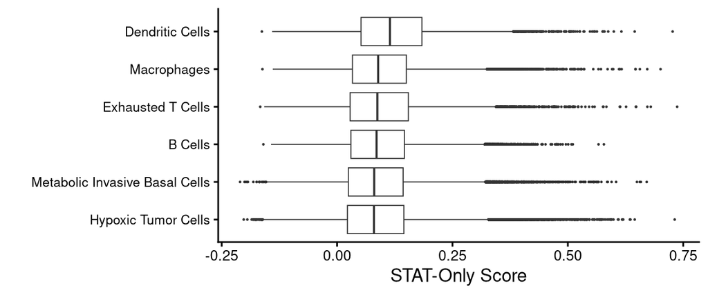

```r
# Filter BEFORE converting to factor
plot_df_top6 <- plot_df %>%
    filter(cell_type %in% top6_cell_types)

# Order the top 6 according to median score
plot_df_top6$cell_type <- factor(
    plot_df_top6$cell_type,
    levels = top6_cell_types
)

# Safety check
stopifnot(!any(is.na(plot_df_top6$cell_type)))

# Plot
boxplot_ranked_cell_types <- ggplot(
    plot_df_top6,
    aes(
        x = cell_type,
        y = stat_only1
    )
) +
    geom_boxplot(
        outlier.size = 0.1,
        linewidth = 0.3
    ) +
    coord_flip() +
    theme_classic() +
    labs(
        x = "",
        y = "STAT-Only Score"
    ) +
    theme(
        axis.text.y = element_text(size = 8)
    )

boxplot_ranked_cell_types
```

```r
pdf(paste0(path2figures,
           "/ranked_cell_types_stat_only_cc.pdf"),
    width=6, height=2.5)
boxplot_ranked_cell_types
dev.off()
```

The Seurat object is no longer needed.

```r
rm(seurat_xenium); invisible(gc())
```

## Panel: STAT-only score vs. distance to RIG-I-high cells

Loading the per-cell table with the scanpy RIG-I-only / STAT-only scores and the distances to the nearest RIG-I-high / RIG-I-low cell (see *Input data*).

```r
path2scores_radius <- "/media/bq-storage/ag-cherrmann/cramirez/data/spat_trans/cervical_cancer/stat_scores_by_spatial_distance.tsv"
scores_radious <- readr::read_tsv(path2scores_radius)
str(scores_radious)
```

```
## spc_tbl_ [717,283 × 13] (S3: spec_tbl_df/tbl_df/tbl/data.frame)
##  $ cell_id                : chr [1:717283] "aaaaahkl-1" "aaaabeha-1" "aaaabmoe-1" "aaaacmod-1" ...
##  $ rigi_score             : num [1:717283] 0.01115 0.01816 0.04172 0.0081 -0.00417 ...
##  $ stat_score             : num [1:717283] 0.0626 0.1206 0.0775 0.0729 0.0962 ...
##  $ celltype               : chr [1:717283] "Hypoxic Tumor Cells" "Hypoxic Tumor Cells" "Hypoxic Tumor Cells" "Hypoxic Tumor Cells" ...
##  $ x                      : num [1:717283] 24.6 21.4 27.3 16.8 19.8 ...
##  $ y                      : num [1:717283] 357 372 369 397 407 ...
##  $ rigi_high              : logi [1:717283] FALSE FALSE FALSE FALSE FALSE FALSE ...
##  $ distance_to_rigi_high  : num [1:717283] 11.9 18.4 19.9 14.4 18.4 ...
##  $ distance_band          : chr [1:717283] "0–25 µm" "0–25 µm" "0–25 µm" "0–25 µm" ...
##  $ rigi_low               : logi [1:717283] FALSE FALSE FALSE FALSE FALSE FALSE ...
##  $ distance_to_rigi_low   : num [1:717283] 13.1 25.4 24.7 46 37.7 ...
##  $ distance_band_rigi_high: chr [1:717283] "0–25 µm" "0–25 µm" "0–25 µm" "0–25 µm" ...
##  $ distance_band_rigi_low : chr [1:717283] "0–25 µm" "25–50 µm" "0–25 µm" "25–50 µm" ...
##  - attr(*, "spec")=
##   .. cols(
##   ..   cell_id = col_character(),
##   ..   rigi_score = col_double(),
##   ..   stat_score = col_double(),
##   ..   celltype = col_character(),
##   ..   x = col_double(),
##   ..   y = col_double(),
##   ..   rigi_high = col_logical(),
##   ..   distance_to_rigi_high = col_double(),
##   ..   distance_band = col_character(),
##   ..   rigi_low = col_logical(),
##   ..   distance_to_rigi_low = col_double(),
##   ..   distance_band_rigi_high = col_character(),
##   ..   distance_band_rigi_low = col_character()
##   .. )
##  - attr(*, "problems")=<externalptr>
```

Each cell contributes one STAT score per reference (its distance band to the nearest RIG-I-high cell and to the nearest RIG-I-low cell).

```r
# Prepare data
plot_data <- scores_radious %>%
  select(
    stat_score,
    distance_band_rigi_high,
    distance_band_rigi_low
  ) %>%
  pivot_longer(
    cols = c(distance_band_rigi_high, distance_band_rigi_low),
    names_to = "rigi_reference",
    values_to = "distance_band"
  ) %>%
  mutate(
    rigi_reference = recode(
      rigi_reference,
      distance_band_rigi_high = "RIG-I-high",
      distance_band_rigi_low  = "RIG-I-low"
    ),
    distance_band = factor(
      distance_band,
      levels = c(
        "0–25 µm",
        "25–50 µm",
        "50–75 µm",
        "75–100 µm",
        "100–150 µm",
        "150–200 µm",
        "200–300 µm",
        "300–400 µm",
        "400–500 µm",
        "≥500 µm"
      )
    )
  )

# Calculate median and IQR for each distance band and RIG-I reference
plot_summary <- plot_data %>%
  group_by(distance_band, rigi_reference) %>%
  summarise(
    median_stat = median(stat_score, na.rm = TRUE),
    q1 = quantile(stat_score, 0.25, na.rm = TRUE),
    q3 = quantile(stat_score, 0.75, na.rm = TRUE),
    .groups = "drop"
  )
plot_summary
```

```
## # A tibble: 14 × 5
##    distance_band rigi_reference median_stat        q1      q3
##    <fct>         <chr>                <dbl>     <dbl>   <dbl>
##  1 0–25 µm       RIG-I-high         0.0363   0.0163    0.0582
##  2 0–25 µm       RIG-I-low          0.0350   0.0150    0.0561
##  3 25–50 µm      RIG-I-high         0.0354   0.0156    0.0558
##  4 25–50 µm      RIG-I-low          0.0361   0.0162    0.0578
##  5 50–75 µm      RIG-I-high         0.0310   0.0116    0.0515
##  6 50–75 µm      RIG-I-low          0.0370   0.0184    0.0594
##  7 75–100 µm     RIG-I-high         0.0239   0.00522   0.0441
##  8 75–100 µm     RIG-I-low          0.0385   0.0196    0.0627
##  9 100–150 µm    RIG-I-high         0.0173   0.000601  0.0383
## 10 100–150 µm    RIG-I-low          0.0381   0.0194    0.0625
## 11 150–200 µm    RIG-I-high         0.00251 -0.00747   0.0137
## 12 150–200 µm    RIG-I-low          0.0365   0.0194    0.0607
## 13 200–300 µm    RIG-I-high        -0.0141  -0.0141   -0.0141
## 14 200–300 µm    RIG-I-low          0.0464   0.0162    0.0644
```

```r
readr::write_tsv(plot_summary,
                 file.path(path2analysis, "stat_score_by_distance_band_summary.tsv"))
```

Wilcoxon rank-sum test (RIG-I-high vs. RIG-I-low reference) within each distance band, BH-adjusted, and the median/IQR plot (`distance_to_rigi_high.pdf`). As in the original panel, the test results are computed but not drawn on the plot.

```r
# ---------------------------------------------------------
# 1. Statistical test
# ---------------------------------------------------------

# One observation per cell for each RIG-I reference
test_data <- scores_radious %>%
  select(
    cell_id,
    stat_score,
    distance_band_rigi_high,
    distance_band_rigi_low
  ) %>%
  pivot_longer(
    cols = c(
      distance_band_rigi_high,
      distance_band_rigi_low
    ),
    names_to = "rigi_reference",
    values_to = "distance_band"
  ) %>%
  mutate(
    rigi_reference = recode(
      rigi_reference,
      distance_band_rigi_high = "RIG-I-high",
      distance_band_rigi_low  = "RIG-I-low"
    )
  ) %>%
  filter(
    !is.na(stat_score),
    !is.na(distance_band)
  )


# Wilcoxon rank-sum test within each distance band
test_results <- test_data %>%
  group_by(distance_band) %>%
  summarise(
    n_high = sum(rigi_reference == "RIG-I-high"),
    n_low  = sum(rigi_reference == "RIG-I-low"),

    median_high = median(
      stat_score[rigi_reference == "RIG-I-high"],
      na.rm = TRUE
    ),

    median_low = median(
      stat_score[rigi_reference == "RIG-I-low"],
      na.rm = TRUE
    ),

    p_value = wilcox.test(
      stat_score ~ rigi_reference,
      data = cur_data(),
      exact = FALSE
    )$p.value,

    .groups = "drop"
  ) %>%
  mutate(
    p_adj = p.adjust(
      p_value,
      method = "BH"
    ),

    significance = case_when(
      p_adj < 0.001 ~ "***",
      p_adj < 0.01  ~ "**",
      p_adj < 0.05  ~ "*",
      TRUE          ~ "ns"
    )
  )
test_results
```

```
## # A tibble: 7 × 8
##   distance_band n_high  n_low median_high median_low   p_value     p_adj
##   <chr>          <int>  <int>       <dbl>      <dbl>     <dbl>     <dbl>
## 1 0–25 µm       437654 532383     0.0363      0.0350 4.30e-137 1.00e-136
## 2 100–150 µm      1742   6168     0.0173      0.0381 5.11e-136 8.94e-136
## 3 150–200 µm        14    553     0.00251     0.0365 1.19e-  4 1.39e-  4
## 4 200–300 µm         1     22    -0.0141      0.0464 1.32e-  1 1.32e-  1
## 5 25–50 µm      218030 124814     0.0354      0.0361 2.45e- 26 3.43e- 26
## 6 50–75 µm       50800  39077     0.0310      0.0370 3.65e-267 1.28e-266
## 7 75–100 µm       9042  14266     0.0239      0.0385 7.93e-320 5.55e-319
## # ℹ 1 more variable: significance <chr>
```

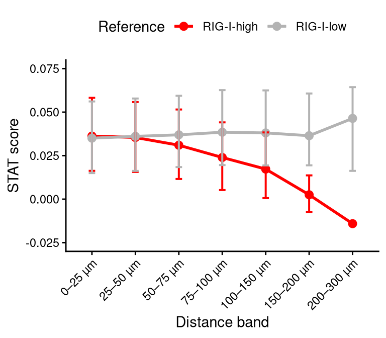

```r
readr::write_tsv(test_results,
                 file.path(path2analysis, "stat_score_rigi_high_vs_low_wilcoxon.tsv"))

# ---------------------------------------------------------
# 2. Plot
# ---------------------------------------------------------

p <- plot_summary %>%
        mutate(rigi_reference=factor(rigi_reference,
                                     levels = c("RIG-I-high",
                                                "RIG-I-low"))) %>%
        ggplot(
  aes(
    x = distance_band,
    y = median_stat,
    color = rigi_reference,
    group = rigi_reference
  )
) +
  geom_line(linewidth = 1) +

  geom_point(
    size = 2.5
  ) +

  geom_errorbar(
    aes(
      ymin = q1,
      ymax = q3
    ),
    width = 0.15,
    linewidth = 0.7
  ) +

  coord_cartesian(
    ylim = c(-0.025, 0.075)
  ) +

  scale_color_manual(
    values = c(
      "RIG-I-high" = "red",
      "RIG-I-low" = "gray70"
    )
  ) +

  labs(
    x = "Distance band",
    y = "STAT score",
    color = "Reference"
  ) +

  theme_classic() +

  theme(
    axis.text.x = element_text(
      angle = 45,
      hjust = 1
    ),
    legend.position = "top"
  )

p
```

```r
pdf(file = paste0(path2figures, "/distance_to_rigi_high.pdf"),
    width=4, height=3.5)
p
dev.off()
```